# Introdução

### Pesquisa Nacional por Amostra de Domicílios - 2015

A **Pesquisa Nacional por Amostra de Domicílios - PNAD** investiga anualmente, de forma permanente, características gerais da população, de educação, trabalho, rendimento e habitação e outras, com periodicidade variável, de acordo com as necessidades de informação para o país, como as características sobre migração, fecundidade, nupcialidade, saúde, segurança alimentar, entre outros temas. O levantamento dessas estatísticas constitui, ao longo dos 49 anos de realização da pesquisa, um importante instrumento para formulação, validação e avaliação de políticas orientadas para o desenvolvimento socioeconômico e a melhoria das condições de vida no Brasil.

```python
import warnings
warnings.filterwarnings("ignore")
```

### Renda

Rendimento mensal do trabalho principal para pessoas de 10 anos ou mais de idade.

### Idade

Idade do morador na data de referência em anos.

### Altura (elaboração própria)

Altura do morador em metros.

### UF

| Código | Descrição |
| --- | --- |
| 11 | Rondônia |
| 12 | Acre |
| 13 | Amazonas |
| 14 | Roraima |
| 15 | Pará |
| 16 | Amapá |
| 17 | Tocantins |
| 21 | Maranhão |
| 22 | Piauí |
| 23 | Ceará |
| 24 | Rio Grande do Norte |
| 25 | Paraíba |
| 26 | Pernambuco |
| 27 | Alagoas |
| 28 | Sergipe |
| 29 | Bahia |
| 31 | Minas Gerais |
| 32 | Espírito Santo |
| 33 | Rio de Janeiro |
| 35 | São Paulo |
| 41 | Paraná |
| 42 | Santa Catarina |
| 43 | Rio Grande do Sul |
| 50 | Mato Grosso do Sul |
| 51 | Mato Grosso |
| 52 | Goiás |
| 53 | Distrito Federal |

### Sexo

| Código | Descrição |
| --- | --- |
| 0 | Masculino |
| 1 | Feminino |

### Anos de Estudo

| Código | Descrição |
| --- | --- |
| 1 | Sem instrução e menos de 1 ano |
| 2 | 1 ano |
| 3 | 2 anos |
| 4 | 3 anos |
| 5 | 4 anos |
| 6 | 5 anos |
| 7 | 6 anos |
| 8 | 7 anos |
| 9 | 8 anos |
| 10 | 9 anos |
| 11 | 10 anos |
| 12 | 11 anos |
| 13 | 12 anos |
| 14 | 13 anos |
| 15 | 14 anos |
| 16 | 15 anos ou mais |
| 17 | Não determinados |
|  | Não aplicável |

### Cor

| Código | Descrição |
| --- | --- |
| 0 | Indígena |
| 2 | Branca |
| 4 | Preta |
| 6 | Amarela |
| 8 | Parda |
| 9 | Sem declaração |

#### Dicionáros das variáveis

```python
sexo = {
    0: 'Masculino',
    1: 'Feminino'
}
cor = {
    0: 'Indígena',
    2: 'Branca',
    4: 'Preta',
    6: 'Amarela',
    8: 'Parda',
    9: 'Sem declaração'
}
anos_de_estudo = {
    1: 'Sem instrução e menos de 1 ano',
    2: '1 ano',
    3: '2 anos',
    4: '3 anos',
    5: '4 anos',
    6: '5 anos',
    7: '6 anos',
    8: '7 anos',
    9: '8 anos',
    10: '9 anos',
    11: '10 anos',
    12: '11 anos',
    13: '12 anos',
    14: '13 anos',
    15: '14 anos',
    16: '15 anos ou mais',
    17: 'Não determinados'
}
uf = {
    11: 'Rondônia',
    12: 'Acre',
    13: 'Amazonas',
    14: 'Roraima',
    15: 'Pará',
    16: 'Amapá',
    17: 'Tocantins',
    21: 'Maranhão',
    22: 'Piauí',
    23: 'Ceará',
    24: 'Rio Grande do Norte',
    25: 'Paraíba',
    26: 'Pernambuco',
    27: 'Alagoas',
    28: 'Sergipe',
    29: 'Bahia',
    31: 'Minas Gerais',
    32: 'Espírito Santo',
    33: 'Rio de Janeiro',
    35: 'São Paulo',
    41: 'Paraná',
    42: 'Santa Catarina',
    43: 'Rio Grande do Sul',
    50: 'Mato Grosso do Sul',
    51: 'Mato Grosso',
    52: 'Goiás',
    53: 'Distrito Federal'
}
```

Classes de renda:

**A** ► Acima de 25 SM

**B** ► De 15 a 25 SM

**C** ► De 5 a 15 SM

**D** ► De 2 a 5 SM

**E** ► Até 2 SM

#### Importando dados

```python
# !pip install pandas
# !pip install seaborn
# !pip install matplotlib
```

```python
import pandas as pd
import seaborn as sns
import matplotlib.pyplot as plt
import numpy as np
```

```python
dados = pd.read_csv('dados/dados.csv')
dados.head()
```

|  | UF | Sexo | Idade | Cor | Anos de Estudo | Renda | Altura |
| --- | --- | --- | --- | --- | --- | --- | --- |
| 0 | 11 | 0 | 23 | 8 | 12 | 800 | 1.603808 |
| 1 | 11 | 1 | 23 | 2 | 12 | 1150 | 1.739790 |
| 2 | 11 | 1 | 35 | 8 | 15 | 880 | 1.760444 |
| 3 | 11 | 0 | 46 | 2 | 6 | 3500 | 1.783158 |
| 4 | 11 | 1 | 47 | 8 | 9 | 150 | 1.690631 |

#### Renomenado o dataframe

```python
dados = dados.replace({'UF': uf,'Sexo' : sexo, 'Cor' : cor})
dados
```

|  | UF | Sexo | Idade | Cor | Anos de Estudo | Renda | Altura |
| --- | --- | --- | --- | --- | --- | --- | --- |
| 0 | Rondônia | Masculino | 23 | Parda | 12 | 800 | 1.603808 |
| 1 | Rondônia | Feminino | 23 | Branca | 12 | 1150 | 1.739790 |
| 2 | Rondônia | Feminino | 35 | Parda | 15 | 880 | 1.760444 |
| 3 | Rondônia | Masculino | 46 | Branca | 6 | 3500 | 1.783158 |
| 4 | Rondônia | Feminino | 47 | Parda | 9 | 150 | 1.690631 |
| ... | ... | ... | ... | ... | ... | ... | ... |
| 76835 | Distrito Federal | Feminino | 46 | Branca | 11 | 812 | 1.687030 |
| 76836 | Distrito Federal | Masculino | 30 | Preta | 7 | 1500 | 1.792934 |
| 76837 | Distrito Federal | Masculino | 32 | Parda | 12 | 1300 | 1.830587 |
| 76838 | Distrito Federal | Masculino | 57 | Parda | 4 | 1500 | 1.726344 |
| 76839 | Distrito Federal | Masculino | 38 | Parda | 4 | 900 | 1.658305 |

76840 rows × 7 columns

#### Obtendo informações dos dados

```python
dados.info()
```

```
<class 'pandas.core.frame.DataFrame'>
RangeIndex: 76840 entries, 0 to 76839
Data columns (total 7 columns):
 #   Column          Non-Null Count  Dtype
---  ------          --------------  -----
 0   UF              76840 non-null  object
 1   Sexo            76840 non-null  object
 2   Idade           76840 non-null  int64
 3   Cor             76840 non-null  object
 4   Anos de Estudo  76840 non-null  int64
 5   Renda           76840 non-null  int64
 6   Altura          76840 non-null  float64
dtypes: float64(1), int64(3), object(3)
memory usage: 4.1+ MB
```

#### A coluna altura foi removida, pois ela tinha sido inserida afim de testes estatísticos.

```python
dados.drop(columns=['Altura'], inplace=True)
```

#### Definindo os valores em reais

Usand dados.Renda.min(), e max() para pegar o menor valor e o maior.

```python
classe = [
    dados.Renda.min(),
    2*788,
    5*788,
    15*788,
    25*788,
    dados.Renda.max()
]
classe
```

```
[0, 1576, 3940, 11820, 19700, 200000]
```

#### Definindo labels

```python
labels = ['E', 'D', 'C', 'B', 'A']
```

```python
frequencias = pd.cut(x = dados.Renda,
bins = classe,
labels= labels,
include_lowest= True) #inclui o menor valor.
frequencias
```

```
0        E
1        E
2        E
3        D
4        E
        ..
76835    E
76836    E
76837    E
76838    E
76839    E
Name: Renda, Length: 76840, dtype: category
Categories (5, object): ['E' < 'D' < 'C' < 'B' < 'A']
```

#### Exibindo a quantidade por classe

```python
frequencias = pd.value_counts(pd.cut(x = dados.Renda,
                            bins = classe,
                            labels= labels,
                            include_lowest= True)) #inclui o menor valor.
frequencias
```

```
E    49755
D    18602
C     7241
B      822
A      420
Name: Renda, dtype: int64
```

```python
frequencias = pd.DataFrame(frequencias)
frequencias
```

|  | Renda |
| --- | --- |
| E | 49755 |
| D | 18602 |
| C | 7241 |
| B | 822 |
| A | 420 |

#### Construindo tabela de percentuais

```python
percentual = pd.value_counts(pd.cut(x = dados.Renda,
bins = classe,
labels= labels,
include_lowest= True),
normalize= True) * 100

percentual
```

```
E    64.751432
D    24.208745
C     9.423477
B     1.069755
A     0.546590
Name: Renda, dtype: float64
```

```python
percentual = pd.DataFrame(percentual)
percentual
```

|  | Renda |
| --- | --- |
| E | 64.751432 |
| D | 24.208745 |
| C | 9.423477 |
| B | 1.069755 |
| A | 0.546590 |

```python
percentual.rename(columns= {'Renda' : ' Quantidade (%)'})
```

|  | Quantidade (%) |
| --- | --- |
| E | 64.751432 |
| D | 24.208745 |
| C | 9.423477 |
| B | 1.069755 |
| A | 0.546590 |

# **Analisando renda máxima e minima**

```python
dados.Renda.max()
```

```
200000
```

```python
dados.Renda.min()
```

```
0
```

```python
area = plt.figure()
```

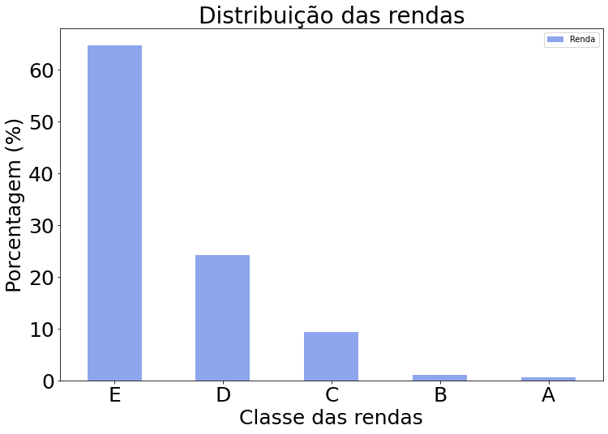

```python
plt.rc('figure', figsize = (12, 8))
fig = percentual.plot.bar(color = 'royalblue', alpha = .6)#Configurações e plotagem
fig.set_title('Distribuição das rendas', {'fontsize' : 28}) #título
fig.set_xlabel('Classe das rendas', {'fontsize' : 25}) # título eixo x
fig.set_ylabel('Porcentagem (%)', {'fontsize' : 25}) #título eixo y
plt.tick_params(labelsize = 25) #aumentando os valores
plt.xticks(rotation = 0) #rotacionando os valores
plt.show()
```

Como fica claro, infelizmente, a classe mais populosa é a E.

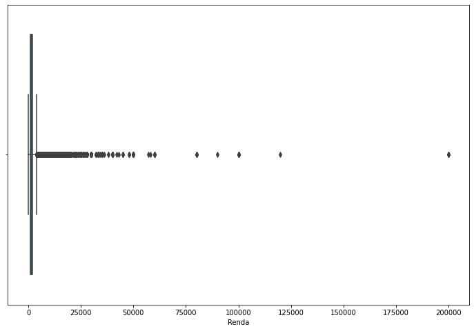

```python
x = sns.boxplot(x = 'Renda', data = dados, orient = 'h')
```

Há possíveis outliers, mas como se trata de renda, vamos filtrar para um valor menor e obter uma melhor visualização.

#### Nova visualização com query

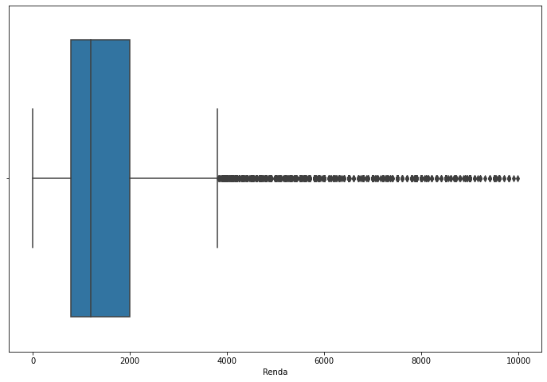

```python
x = sns.boxplot(x = 'Renda', data = dados.query('Renda < 10000'), orient = 'h')
```

Observa-se que, mais ou menos, acima de R$ 3.818,00 já são valores 'descrepantes' para a sociedade brasileira

```python
#Identificando os quartis
Q1 = dados.Renda.quantile(0.25)
Q3 = dados.Renda.quantile(0.75)

IQQ = Q3 - Q1
limite_inferior = Q1 - 1.5 * IQQ
limite_superior = Q3 + 1.5 * IQQ
```

```python
limite_superior
```

```
3818.0
```

# **Distribuição de renda por cor, sexo, anos de esutdo**

```python
frequencia = pd.crosstab(dados.Sexo, dados.Cor)
frequencia
```

| Cor Sexo | Amarela | Branca | Indígena | Parda | Preta |
| --- | --- | --- | --- | --- | --- |
| Feminino | 117 | 9621 | 101 | 10862 | 2889 |
| Masculino | 235 | 22194 | 256 | 25063 | 5502 |

```python
frequencia = pd.crosstab(dados.Sexo,
                         dados.Cor,
                         aggfunc= 'mean', values= dados.query('Renda < 10000').Renda)
frequencia.rename(index = sexo, inplace= True)
frequencia.rename(columns = cor, inplace= True)
frequencia
```

| Cor Sexo | Amarela | Branca | Indígena | Parda | Preta |
| --- | --- | --- | --- | --- | --- |
| Feminino | 2087.841121 | 1700.750134 | 1175.787879 | 1086.942333 | 1078.825104 |
| Masculino | 2966.448276 | 2155.023851 | 1046.737255 | 1473.510780 | 1483.508341 |

#### Observa-se, que, a renda está mais concetrada, independente do sexo, na cor amarela.

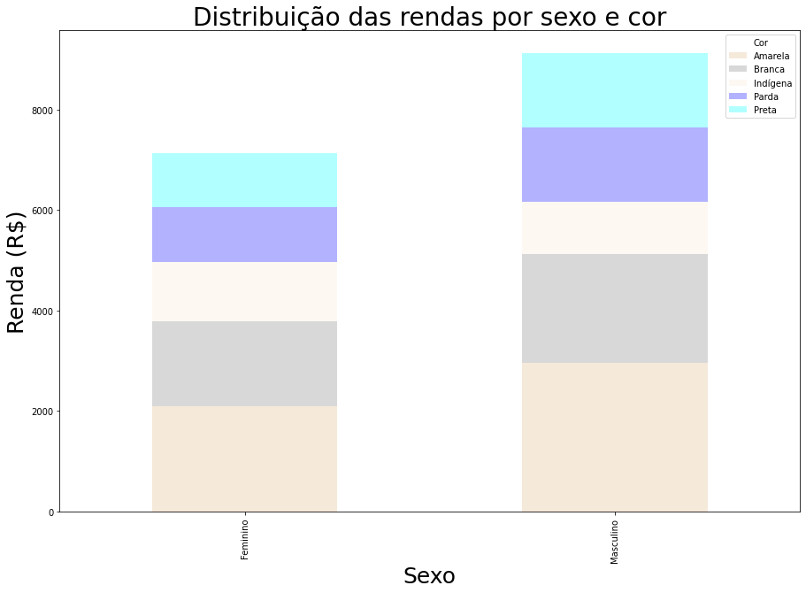

```python
ax = frequencia.plot.bar(stacked = True, color = ['#DEB887', '#808080', '#FAEBD7', '#0000FF', '#00FFFF'], alpha = .3)
ax.figure.set_size_inches(15, 10)
ax.set_title("Distribuição das rendas por sexo e cor", {'fontsize' : 28})
ax.set_ylabel("Renda (R$)", {'fontsize' : 25})
ax.set_xlabel("Sexo", {'fontsize' : 25})
```

```python
plt.rcParams['figure.figsize'] = [2, 2]
ax.figure.savefig('cor.png')
```

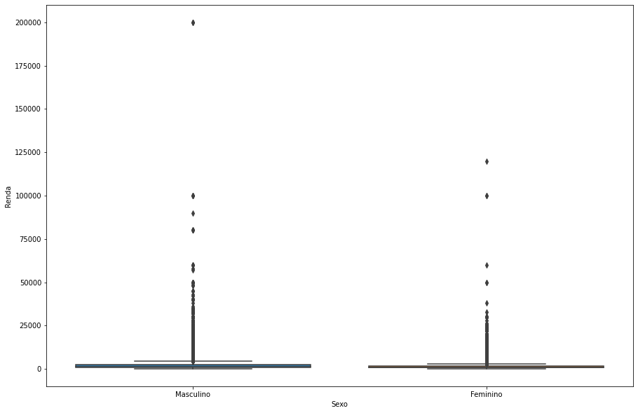

```python
ax = sns.boxplot( y = 'Renda', x = 'Sexo', data = dados)
ax.figure.set_size_inches(15, 10)
```

#### Filtrando renda de até 10000

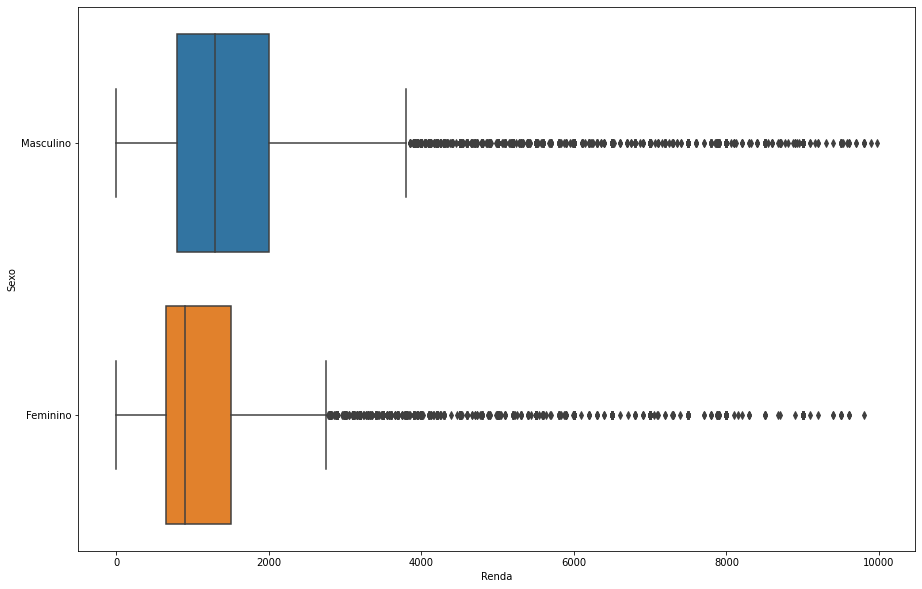

```python
ax = sns.boxplot(x = 'Renda', y = 'Sexo',  data = dados.query('Renda < 10000'), orient = 'h')
ax.figure.set_size_inches(15, 10)
```

```python
dados.head()
```

|  | UF | Sexo | Idade | Cor | Anos de Estudo | Renda |
| --- | --- | --- | --- | --- | --- | --- |
| 0 | Rondônia | Masculino | 23 | Parda | 12 | 800 |
| 1 | Rondônia | Feminino | 23 | Branca | 12 | 1150 |
| 2 | Rondônia | Feminino | 35 | Parda | 15 | 880 |
| 3 | Rondônia | Masculino | 46 | Branca | 6 | 3500 |
| 4 | Rondônia | Feminino | 47 | Parda | 9 | 150 |

#### Por qual motivo os homens ganham mais? Estudam mais que as mulheres? Estão concentrados nos estados que mais pagam?

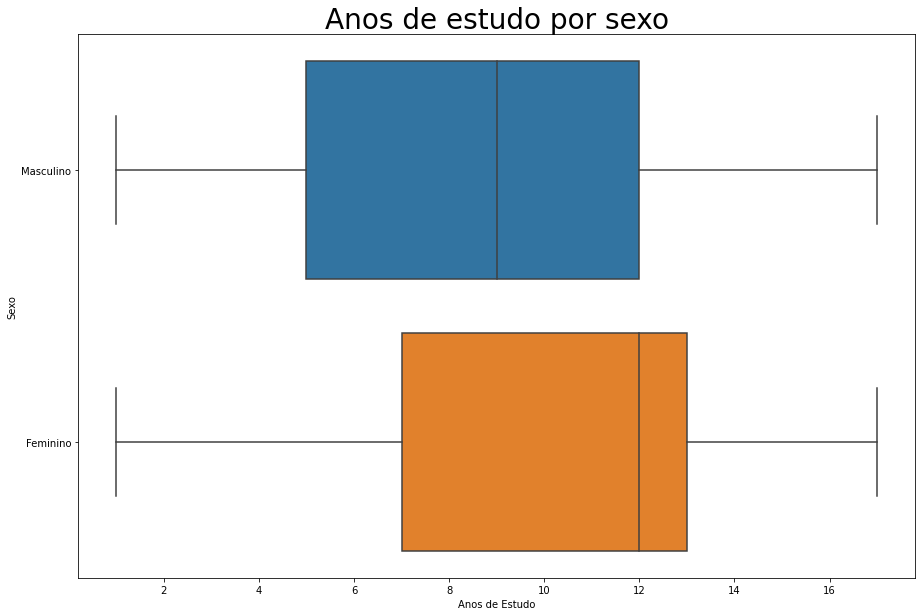

```python
ax = sns.boxplot(x= 'Anos de Estudo', y = 'Sexo', data = dados)
ax.figure.set_size_inches(15, 10)
ax.set_title("Anos de estudo por sexo", {'fontsize' : 28})
```

```python
dados
```

|  | UF | Sexo | Idade | Cor | Anos de Estudo | Renda |
| --- | --- | --- | --- | --- | --- | --- |
| 0 | Rondônia | Masculino | 23 | Parda | 12 | 800 |
| 1 | Rondônia | Feminino | 23 | Branca | 12 | 1150 |
| 2 | Rondônia | Feminino | 35 | Parda | 15 | 880 |
| 3 | Rondônia | Masculino | 46 | Branca | 6 | 3500 |
| 4 | Rondônia | Feminino | 47 | Parda | 9 | 150 |
| ... | ... | ... | ... | ... | ... | ... |
| 76835 | Distrito Federal | Feminino | 46 | Branca | 11 | 812 |
| 76836 | Distrito Federal | Masculino | 30 | Preta | 7 | 1500 |
| 76837 | Distrito Federal | Masculino | 32 | Parda | 12 | 1300 |
| 76838 | Distrito Federal | Masculino | 57 | Parda | 4 | 1500 |
| 76839 | Distrito Federal | Masculino | 38 | Parda | 4 | 900 |

76840 rows × 6 columns

- **Fica evidente, que as mulheres estudam mais e ganham menos**

```python
dfMasc = dados.query('Sexo == "Masculino"')
```

```python
dfMasc.head()
```

|  | UF | Sexo | Idade | Cor | Anos de Estudo | Renda |
| --- | --- | --- | --- | --- | --- | --- |
| 0 | Rondônia | Masculino | 23 | Parda | 12 | 800 |
| 3 | Rondônia | Masculino | 46 | Branca | 6 | 3500 |
| 6 | Rondônia | Masculino | 57 | Parda | 12 | 3150 |
| 9 | Rondônia | Masculino | 26 | Parda | 12 | 1150 |
| 13 | Rondônia | Masculino | 38 | Parda | 12 | 2000 |

```python
dfMasc.sort_values(by =['Renda'], ascending= False, inplace = True)
dfMasc.head()
```

|  | UF | Sexo | Idade | Cor | Anos de Estudo | Renda |
| --- | --- | --- | --- | --- | --- | --- |
| 28110 | Bahia | Masculino | 51 | Branca | 12 | 200000 |
| 56141 | Paraná | Masculino | 42 | Branca | 16 | 200000 |
| 43693 | Rio de Janeiro | Masculino | 79 | Branca | 16 | 200000 |
| 37497 | Minas Gerais | Masculino | 72 | Branca | 16 | 100000 |
| 74867 | Distrito Federal | Masculino | 72 | Branca | 16 | 100000 |

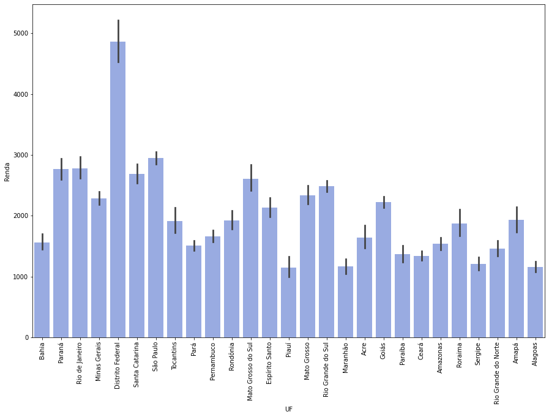

```python
ax = sns.barplot(x = 'UF', y = 'Renda', data = dfMasc, color='royalblue', alpha = .6)
ax.figure.set_size_inches(15, 10)
plt.xticks(rotation = 90)
plt.show()
```

# **Qual região paga mais?**

```python
dfRegiao = dados.groupby(['UF']).Renda.mean().to_frame()
dfRegiao.sort_values(by=['Renda'], inplace= True, ascending= False)
```

```python
dfRegiao
```

| UF | Renda |
| --- | --- |
| Distrito Federal | 4241.954722 |
| São Paulo | 2638.104986 |
| Rio de Janeiro | 2496.403168 |
| Paraná | 2493.870753 |
| Santa Catarina | 2470.854945 |
| Rio Grande do Sul | 2315.158336 |
| Mato Grosso do Sul | 2262.604167 |
| Mato Grosso | 2130.652778 |
| Minas Gerais | 2056.432084 |
| Espírito Santo | 2026.383852 |
| Goiás | 1994.580794 |
| Amapá | 1861.353516 |
| Rondônia | 1789.761223 |
| Roraima | 1783.588889 |
| Tocantins | 1771.094946 |
| Pernambuco | 1527.079319 |
| Acre | 1506.091782 |
| Amazonas | 1445.130100 |
| Bahia | 1429.645094 |
| Pará | 1399.076871 |
| Rio Grande do Norte | 1344.721480 |
| Paraíba | 1293.370487 |
| Ceará | 1255.403692 |
| Alagoas | 1144.552602 |
| Sergipe | 1109.111111 |
| Piauí | 1074.550784 |
| Maranhão | 1019.432009 |

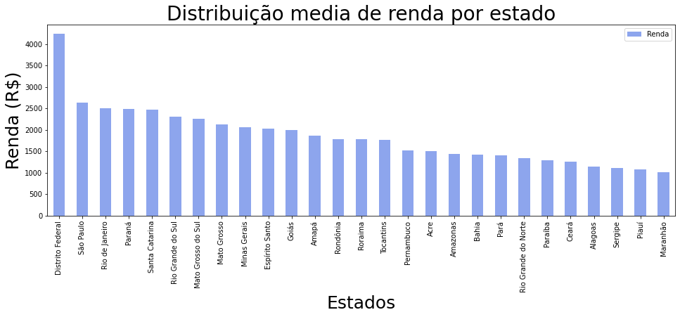

```python
ax = dfRegiao.plot.bar(color = 'royalblue', alpha = .6)#Configurações e plotagem
ax.figure.set_size_inches(16, 5)
ax.set_title('Distribuição media de renda por estado', {'fontsize' : 28}) #título
ax.set_ylabel('Renda (R$)', {'fontsize' : 25})
ax.set_xlabel('Estados', {'fontsize' : 25})
plt.show()
```

## **Analisando o motivo do DF pagar mais**

```python
dfDistrito = dados[(dados.UF =='Distrito Federal')]
dfDistrito
```

|  | UF | Sexo | Idade | Cor | Anos de Estudo | Renda |
| --- | --- | --- | --- | --- | --- | --- |
| 74786 | Distrito Federal | Feminino | 39 | Branca | 16 | 8300 |
| 74787 | Distrito Federal | Feminino | 37 | Parda | 16 | 10000 |
| 74788 | Distrito Federal | Masculino | 46 | Branca | 16 | 14500 |
| 74789 | Distrito Federal | Masculino | 53 | Parda | 16 | 10000 |
| 74790 | Distrito Federal | Masculino | 33 | Branca | 16 | 12000 |
| ... | ... | ... | ... | ... | ... | ... |
| 76835 | Distrito Federal | Feminino | 46 | Branca | 11 | 812 |
| 76836 | Distrito Federal | Masculino | 30 | Preta | 7 | 1500 |
| 76837 | Distrito Federal | Masculino | 32 | Parda | 12 | 1300 |
| 76838 | Distrito Federal | Masculino | 57 | Parda | 4 | 1500 |
| 76839 | Distrito Federal | Masculino | 38 | Parda | 4 | 900 |

2054 rows × 6 columns

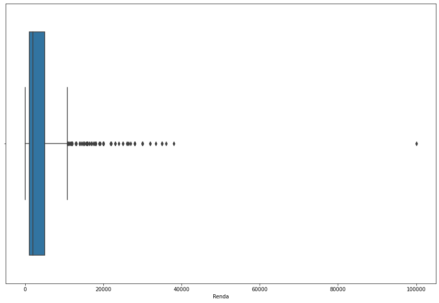

```python
ax = sns.boxplot(x = 'Renda', data = dfDistrito, orient = 'h')
ax.figure.set_size_inches(15, 10)
```

Analisando os outliers do Distrito Federal

```python
Q1 = dfDistrito.Renda.quantile(0.25)
Q2 = dfDistrito.Renda.quantile(0.50)
Q3 = dfDistrito.Renda.quantile(0.75)

limite_inferior =  Q1 - 1.5 * (Q3 - Q1)
limite_superior = Q3 + 1.5 * (Q3 - Q1)
```

```python
limite_inferior
limite_superior.round(2)
```

```
10846.62
```

Como podemos ver, o limite superior é bem alto para o padrão brasileiro. Totalizando R$ 10.846,62

```python
dfDistrito.describe()
```

|  | Idade | Anos de Estudo | Renda |
| --- | --- | --- | --- |
| count | 2054.000000 | 2054.000000 | 2054.000000 |
| mean | 42.734177 | 11.910419 | 4241.954722 |
| std | 11.556609 | 4.148458 | 5550.463338 |
| min | 17.000000 | 1.000000 | 0.000000 |
| 25% | 34.000000 | 9.000000 | 1102.250000 |
| 50% | 42.000000 | 12.000000 | 2000.000000 |
| 75% | 51.000000 | 16.000000 | 5000.000000 |
| max | 81.000000 | 17.000000 | 100000.000000 |

# **Buscando uma possível relação com anos de estudo e salários altos.**

```python
dados.head()
```

|  | UF | Sexo | Idade | Cor | Anos de Estudo | Renda |
| --- | --- | --- | --- | --- | --- | --- |
| 0 | Rondônia | Masculino | 23 | Parda | 12 | 800 |
| 1 | Rondônia | Feminino | 23 | Branca | 12 | 1150 |
| 2 | Rondônia | Feminino | 35 | Parda | 15 | 880 |
| 3 | Rondônia | Masculino | 46 | Branca | 6 | 3500 |
| 4 | Rondônia | Feminino | 47 | Parda | 9 | 150 |

```python
estatísticas = ['mean', 'max', 'min']
```

```python
dfAnos1 = dados.groupby('Anos de Estudo')['Renda']
```

```python
dfAnos1.describe()
```

| Anos de Estudo | count | mean | std | min | 25% | 50% | 75% | max |
| --- | --- | --- | --- | --- | --- | --- | --- | --- |
| 1 | 5849.0 | 732.994187 | 955.274843 | 0.0 | 180.0 | 600.0 | 1000.0 | 30000.0 |
| 2 | 1388.0 | 806.524496 | 1203.866292 | 0.0 | 300.0 | 700.0 | 1000.0 | 30000.0 |
| 3 | 2101.0 | 842.560209 | 1298.873800 | 0.0 | 300.0 | 788.0 | 1000.0 | 40000.0 |
| 4 | 2891.0 | 980.044275 | 1907.138437 | 0.0 | 400.0 | 788.0 | 1200.0 | 80000.0 |
| 5 | 6729.0 | 1150.439293 | 1293.144934 | 0.0 | 560.0 | 900.0 | 1500.0 | 50000.0 |
| 6 | 4499.0 | 1183.575683 | 1328.709017 | 0.0 | 700.0 | 940.0 | 1500.0 | 35000.0 |
| 7 | 2445.0 | 1284.082618 | 1326.140204 | 0.0 | 788.0 | 1000.0 | 1500.0 | 25000.0 |
| 8 | 2689.0 | 1289.166233 | 1279.412081 | 0.0 | 788.0 | 1000.0 | 1500.0 | 40000.0 |
| 9 | 7980.0 | 1437.744862 | 1404.280340 | 0.0 | 788.0 | 1100.0 | 1600.0 | 30000.0 |
| 10 | 1840.0 | 1315.685870 | 1888.373952 | 0.0 | 788.0 | 1000.0 | 1500.0 | 60000.0 |
| 11 | 2118.0 | 1495.901322 | 1817.676555 | 0.0 | 788.0 | 1100.0 | 1600.0 | 45000.0 |
| 12 | 20848.0 | 1841.671287 | 2457.197657 | 0.0 | 900.0 | 1350.0 | 2000.0 | 200000.0 |
| 13 | 1836.0 | 2185.769063 | 3452.732525 | 0.0 | 1000.0 | 1500.0 | 2500.0 | 120000.0 |
| 14 | 1253.0 | 2758.774142 | 2638.840287 | 0.0 | 1200.0 | 2000.0 | 3300.0 | 25000.0 |
| 15 | 1388.0 | 3099.840058 | 3413.359423 | 0.0 | 1350.0 | 2100.0 | 3750.0 | 50000.0 |
| 16 | 10795.0 | 5242.443353 | 6450.490806 | 0.0 | 2000.0 | 3500.0 | 6000.0 | 200000.0 |
| 17 | 191.0 | 1071.717277 | 825.579556 | 0.0 | 769.0 | 900.0 | 1285.0 | 7000.0 |

```python
dados.corr().round(4)
```

|  | Idade | Anos de Estudo | Renda |
| --- | --- | --- | --- |
| Idade | 1.0000 | -0.2676 | 0.0414 |
| Anos de Estudo | -0.2676 | 1.0000 | 0.3322 |
| Renda | 0.0414 | 0.3322 | 1.0000 |

```python
dfAnos = dados.groupby(['Anos de Estudo']).Renda.mean().to_frame().reset_index()
```

```python
dfAnos
```

|  | Anos de Estudo | Renda |
| --- | --- | --- |
| 0 | 1 | 732.994187 |
| 1 | 2 | 806.524496 |
| 2 | 3 | 842.560209 |
| 3 | 4 | 980.044275 |
| 4 | 5 | 1150.439293 |
| 5 | 6 | 1183.575683 |
| 6 | 7 | 1284.082618 |
| 7 | 8 | 1289.166233 |
| 8 | 9 | 1437.744862 |
| 9 | 10 | 1315.685870 |
| 10 | 11 | 1495.901322 |
| 11 | 12 | 1841.671287 |
| 12 | 13 | 2185.769063 |
| 13 | 14 | 2758.774142 |
| 14 | 15 | 3099.840058 |
| 15 | 16 | 5242.443353 |
| 16 | 17 | 1071.717277 |

```
findfont: Font family ['Arial'] not found. Falling back to DejaVu Sans.
findfont: Font family ['Arial'] not found. Falling back to DejaVu Sans.
```

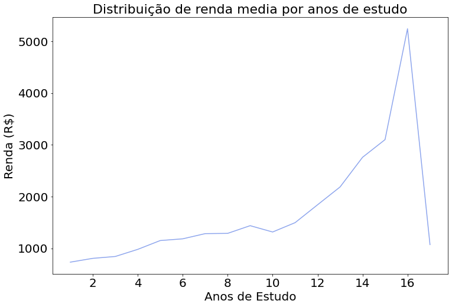

```python
x = dfAnos['Anos de Estudo']
y = dfAnos['Renda']
plt.figure(figsize = (12, 8))
plt.rc('font', family= 'Arial', size = 20)
plt.plot(x, y, color = 'royalblue', alpha = .6)
plt.xlabel('Anos de Estudo', {'fontsize' : 20})
plt.ylabel('Renda (R$)', {'fontsize' : 20})
plt.title('Distribuição de renda media por anos de estudo', {'fontsize' : 22})
```

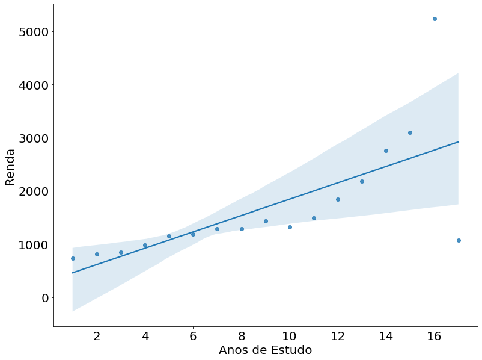

```python
ax = sns.lmplot(x = 'Anos de Estudo', y = 'Renda', data = dfAnos)
ax.figure.set_size_inches(15, 10)
```

Plotando a reta de regressão é possível notar, também, o aumento do salário de acordo com anos de estudo.

```python
dfAnos[(dfAnos['Anos de Estudo'] == 17)]
```

|  | Anos de Estudo | Renda |
| --- | --- | --- |
| 16 | 17 | 1071.717277 |

```python
dfYear = dados[(dados['Anos de Estudo'] == 17)]
dfYear
```

|  | UF | Sexo | Idade | Cor | Anos de Estudo | Renda |
| --- | --- | --- | --- | --- | --- | --- |
| 74 | Rondônia | Masculino | 41 | Parda | 17 | 2000 |
| 188 | Rondônia | Masculino | 38 | Parda | 17 | 1900 |
| 343 | Rondônia | Feminino | 47 | Branca | 17 | 788 |
| 1160 | Rondônia | Masculino | 26 | Branca | 17 | 1200 |
| 1261 | Rondônia | Feminino | 38 | Parda | 17 | 500 |
| ... | ... | ... | ... | ... | ... | ... |
| 75844 | Distrito Federal | Feminino | 56 | Parda | 17 | 300 |
| 76041 | Distrito Federal | Feminino | 22 | Branca | 17 | 788 |
| 76575 | Distrito Federal | Feminino | 45 | Preta | 17 | 1200 |
| 76597 | Distrito Federal | Feminino | 58 | Preta | 17 | 3000 |
| 76674 | Distrito Federal | Feminino | 36 | Parda | 17 | 1200 |

191 rows × 6 columns

```python
dfYear.describe()
```

|  | Idade | Anos de Estudo | Renda |
| --- | --- | --- | --- |
| count | 191.000000 | 191.0 | 191.000000 |
| mean | 38.350785 | 17.0 | 1071.717277 |
| std | 11.910963 | 0.0 | 825.579556 |
| min | 16.000000 | 17.0 | 0.000000 |
| 25% | 30.000000 | 17.0 | 769.000000 |
| 50% | 37.000000 | 17.0 | 900.000000 |
| 75% | 47.000000 | 17.0 | 1285.000000 |
| max | 78.000000 | 17.0 | 7000.000000 |

```python
dfYear.Renda.mean()
```

```
1071.717277486911
```

```python
Q1 = dfYear.Renda.quantile(0.25)
Q2 = dfYear.Renda.quantile(0.50)

limite_inferior = Q1 - 1.5 * (Q2 - Q1)
limite_superior = Q2 + 1.5 * (Q2 - Q1)
```

```python
limite_inferior
```

```
572.5
```

```python
limite_superior
```

```
1096.5
```

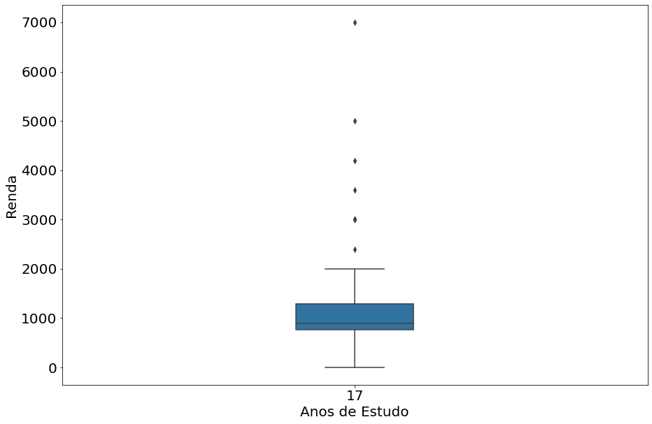

```python
ax = sns.boxplot(x = 'Anos de Estudo', y = 'Renda', data = dfYear, orient='v', width=.2)
ax.figure.set_size_inches(15, 10)
```

```python
dfYear['Renda'].median()
print(f'A mediana de um trabalhador que estuda por 17 anos é de R${dfYear["Renda"].median()}')
```

```
A mediana de um trabalhador que estuda por 17 anos é de R$900.0
```

```python
dfYear['Renda'].mean().__round__(2)
print(f'A média de um trabalhador que estuda por 17 anos é de R${dfYear["Renda"].mean().__round__(2)}')
```

```
A média de um trabalhador que estuda por 17 anos é de R$1071.72
```

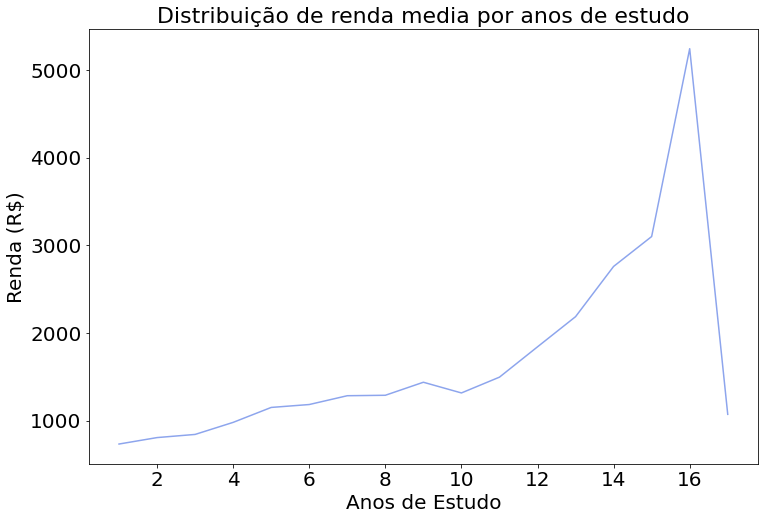

```python
x = dfAnos['Anos de Estudo']
y = dfAnos['Renda']
plt.figure(figsize = (12, 8))
plt.rc('font', family= 'Arial', size = 20)
plt.plot(x, y, color = 'royalblue', alpha = .6)
plt.xlabel('Anos de Estudo', {'fontsize' : 20})
plt.ylabel('Renda (R$)', {'fontsize' : 20})
plt.title('Distribuição de renda media por anos de estudo', {'fontsize' : 22})
```

## **Renda máxima**

```python
dfYear_16 = dados[(dados['Anos de Estudo'] == 16)]
dfYear_16
```

|  | UF | Sexo | Idade | Cor | Anos de Estudo | Renda |
| --- | --- | --- | --- | --- | --- | --- |
| 15 | Rondônia | Masculino | 34 | Branca | 16 | 6000 |
| 17 | Rondônia | Masculino | 53 | Parda | 16 | 7000 |
| 21 | Rondônia | Feminino | 41 | Parda | 16 | 4000 |
| 26 | Rondônia | Masculino | 33 | Branca | 16 | 1600 |
| 54 | Rondônia | Feminino | 46 | Branca | 16 | 4800 |
| ... | ... | ... | ... | ... | ... | ... |
| 76825 | Distrito Federal | Masculino | 55 | Branca | 16 | 13000 |
| 76827 | Distrito Federal | Feminino | 41 | Branca | 16 | 10000 |
| 76828 | Distrito Federal | Masculino | 62 | Branca | 16 | 10000 |
| 76830 | Distrito Federal | Masculino | 62 | Branca | 16 | 3500 |
| 76831 | Distrito Federal | Feminino | 44 | Branca | 16 | 30000 |

10795 rows × 6 columns

#### Observa-se a diferença dos dados em relação a renda. O valor máximo de renda é 200000. Irei analisar a fundo essa declaração.

```python
dfYear_16.describe()
```

|  | Idade | Anos de Estudo | Renda |
| --- | --- | --- | --- |
| count | 10795.000000 | 10795.0 | 10795.000000 |
| mean | 44.129041 | 16.0 | 5242.443353 |
| std | 11.179367 | 0.0 | 6450.490806 |
| min | 20.000000 | 16.0 | 0.000000 |
| 25% | 35.000000 | 16.0 | 2000.000000 |
| 50% | 43.000000 | 16.0 | 3500.000000 |
| 75% | 52.000000 | 16.0 | 6000.000000 |
| max | 92.000000 | 16.0 | 200000.000000 |

```python
dfMax = dados[(dados.Renda == 200000)]
dfMax
```

|  | UF | Sexo | Idade | Cor | Anos de Estudo | Renda |
| --- | --- | --- | --- | --- | --- | --- |
| 28110 | Bahia | Masculino | 51 | Branca | 12 | 200000 |
| 43693 | Rio de Janeiro | Masculino | 79 | Branca | 16 | 200000 |
| 56141 | Paraná | Masculino | 42 | Branca | 16 | 200000 |

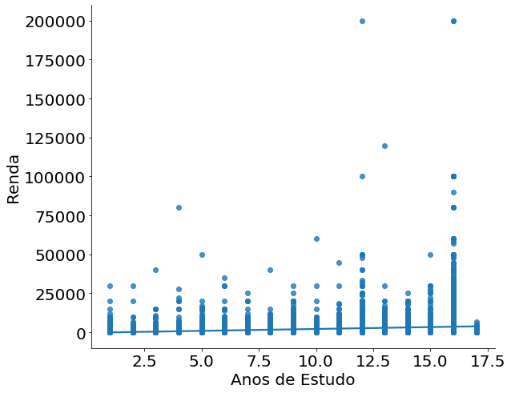

```python
ax = sns.lmplot(x = 'Anos de Estudo', y = 'Renda', data = dados)
ax.figure.set_size_inches(12, 8)
plt.show()
```

#### Essa informação pode ser verdadeira, pois são homens (homens ganham mais) e são da Etnia branca (segundo grupo que mais ganha)

# **Em qual estado os estudantes estudam por mais tempo?**

```python
dfEstudos = dados.groupby(['UF'])['Anos de Estudo'].mean().to_frame().reset_index()
dfEstudos
```

|  | UF | Anos de Estudo |
| --- | --- | --- |
| 0 | Acre | 8.398079 |
| 1 | Alagoas | 7.838317 |
| 2 | Amapá | 10.050781 |
| 3 | Amazonas | 9.361741 |
| 4 | Bahia | 8.725730 |
| 5 | Ceará | 8.665079 |
| 6 | Distrito Federal | 11.910419 |
| 7 | Espírito Santo | 9.466578 |
| 8 | Goiás | 9.435883 |
| 9 | Maranhão | 7.518747 |
| 10 | Mato Grosso | 9.472778 |
| 11 | Mato Grosso do Sul | 9.509028 |
| 12 | Minas Gerais | 9.129846 |
| 13 | Paraná | 10.084252 |
| 14 | Paraíba | 8.165620 |
| 15 | Pará | 8.672286 |
| 16 | Pernambuco | 9.214921 |
| 17 | Piauí | 7.014038 |
| 18 | Rio Grande do Norte | 8.823227 |
| 19 | Rio Grande do Sul | 10.104556 |
| 20 | Rio de Janeiro | 10.547516 |
| 21 | Rondônia | 8.811971 |
| 22 | Roraima | 9.916667 |
| 23 | Santa Catarina | 10.226813 |
| 24 | Sergipe | 7.337995 |
| 25 | São Paulo | 10.639045 |
| 26 | Tocantins | 9.027565 |

```python
dfEstudos = dfEstudos.sort_values(by = 'Anos de Estudo', ascending = False)
```

```
findfont: Font family ['Arial'] not found. Falling back to DejaVu Sans.
findfont: Font family ['Arial'] not found. Falling back to DejaVu Sans.
```

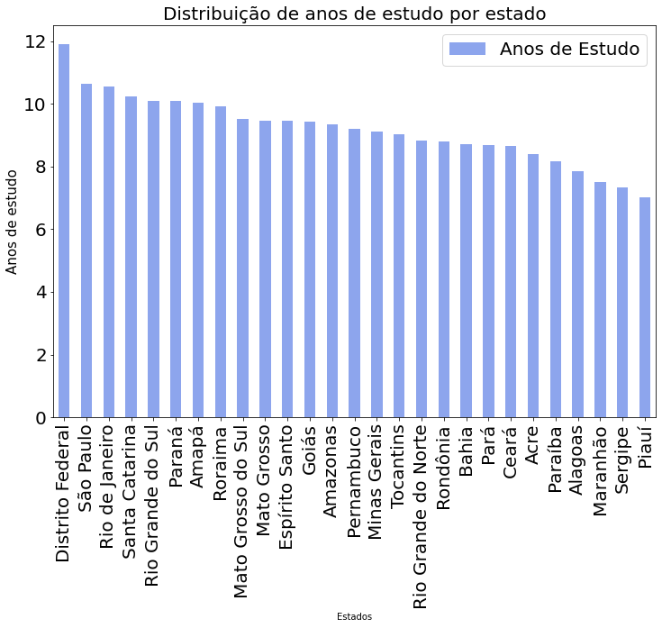

```python
ax = dfEstudos.plot.bar(x = 'UF', y = 'Anos de Estudo', color = 'royalblue', alpha = .6)
ax.figure.set_size_inches(12, 8)
ax.set_title('Distribuição de anos de estudo por estado', {'fontsize' : 20})
ax.set_ylabel("Anos de estudo", {'fontsize' : 15})
ax.set_xlabel("Estados", {'fontsize' : 10})
plt.show()
```